# Comparing Time Series Forecasting Techniques

## Introduction

A time series is a sequence of numerical data points in successive order. Time series analysis helps to identify the pattern or nature of the phenomenon represented by the sequence of observations. It can be used to understand the past and predict the future. The purpose of this notebook is to illustrate the use of different time series prediction techniques in forecasting future short-term item-level sales given 5 years of store-item sales data. Let’s begin!

## Getting Started

Load required libraries

```r
oldw <- getOption("warn")
options(warn = -1)

library(lubridate)
library(ggplot2)
library(zoo)
library(plotly)
library(plyr)
library(magrittr)
library(dplyr)
library(fpp)
library(forecast)
library(Matrix)
library(xgboost)
library(RcppRoll)
library(DiagrammeR)
library(data.table)
library(Metrics)
library(TSA)
library(tseries)
library(pdR)
library(uroot)
library(IRdisplay)
```

### Understanding the data

The data provided contains the following fields:

**date** - Date of the sale data. There are no holiday effects or store closures.  
**store** - Store ID  
**item** - Item ID  
**sales** - Number of items sold at a particular store on a particular date.

The given dataset contains sales data of 10 stores with 50 items for each store. Ideally, we could use the whole dataset but for this notebook we will be using only the sales data of store 1 item 1 as the benchmark dataset for comparing different techniques.

```r
train_data <- read.csv('train.csv',header = TRUE)
train_data = train_data %>% filter( store == 1 & item == 1)
head(train_data)
```

| date | store | item | sales |
| --- | --- | --- | --- |
| 2013-01-01 | 1 | 1 | 13 |
| 2013-01-02 | 1 | 1 | 11 |
| 2013-01-03 | 1 | 1 | 14 |
| 2013-01-04 | 1 | 1 | 13 |
| 2013-01-05 | 1 | 1 | 10 |
| 2013-01-06 | 1 | 1 | 12 |

```r
dim(train_data)
```

1. 1826

2. 4

```r
# partition data into train and test data
partition_index <- length(train_data$sales) - 90

sales_train_data <- train_data$sales[1:partition_index]
sales_test_data <- train_data$sales[(partition_index+1):length(train_data$sales)]
```

## Exploring the time series

Let's plot the time series data and check its characteristics.

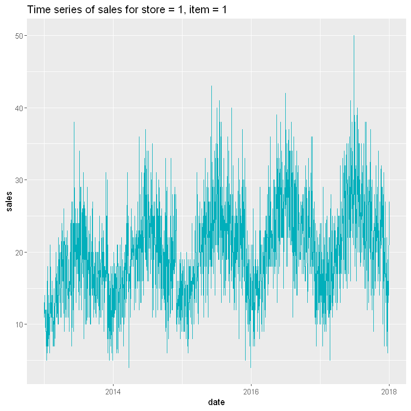

```r
train_data$date <- as.Date(as.character(train_data$date))

ggplot(data = train_data, aes(x = date, y = sales))+
  geom_line(color = "#00AFBB", size = 0.1) +
  ggtitle("Time series of sales for store = 1, item = 1")
```

> We can clearly see there is a upward trend and contains a fairly obvious seasonality.

The following plots allow us to visually examine the trend variation of monthly and weekly sales.

**Yearly sales by month plot**

```r
train_data$date <- as.Date(train_data$date)
train_data['month'] = month(train_data$date)
train_data['year'] = year(train_data$date)
train_data['week'] = week(train_data$date)

plot_data <- train_data %>% group_by(year,month) %>% summarize(sales = mean(sales))

plot_data$month <- factor(plot_data$month)
levels(plot_data$month) <- month.abb

temp <- plot_data
colnames(temp)[2] <- "groupVar"

p <- ggplot(plot_data,aes(x = year, y = sales)) +
     geom_line(data = temp, aes(x = year, y = sales, group = groupVar),
                       colour = "GRAY", alpha = 1/2, size = 1/2) +
     geom_line(size = 1) +
    facet_wrap(~ month) +
    ggtitle("Monthly sales")

htmlwidgets::saveWidget(ggplotly(p), "plot1.html")
display_html('<iframe src="plot1.html" width=100% height=480 frameBorder="0"></iframe>')
```

[interactive chart not shown]

**Weekly sales by year plot**

```r
plot_data <- train_data %>% group_by(year,month,week) %>% summarize(sales = mean(sales),date =first(date))
plot_data['m_day'] <- mday(plot_data$date)
plot_data['common_date'] <- as.Date(paste0("2013-",format(plot_data$date, "%j")), "%Y-%j")

plot_data$year <- as.character(plot_data$year)
p <- ggplot(data = plot_data,
       mapping = aes(x = common_date, y = sales, shape = year, colour = year)) +
    xlab("date") +
    ggtitle("Weekly sales by year") +
    geom_point() +
    geom_line() +
    facet_grid(facets = year ~ .) +
    scale_x_date(labels = function(x) format(x, "%d-%b"))


htmlwidgets::saveWidget(ggplotly(p), "plot2.html")
display_html('<iframe src="plot2.html" width=100% height=500 frameBorder="0"></iframe>')
```

[interactive chart not shown]

## Time series analysis and modeling

For time series prediction, we will be using and comparing three common prediction techniques which are Holt-Winters Exponential Smoothing, ARIMA and XGBoost.

**Decompose the time series**

The first step is to decompose the data to extract the components of time series. The four components of a time series are trend, sesonality, cycle and residuals. Trend component refers to the overall pattern of the series. Seasonal component is the fluctuations in the data related to calendar cycles. Cycle component consists of decreasing or increasing patterns that are not seasonal, which is usually grouped together with trend component. Finally, residuals that can't be attributed to the three components above. These components are crutial in time series analysis as it captures the historical patterns in the series.

For our data, additive decomposition is the most appropriate since the seasonal flunctuation and random variations seem to be constant in size over time. We can plot the estimated trend, seasonal, and irregular components of the time series by using the *decompose* function, for example:

```r
# Create a time series object from sales data
sales_ts <- ts(sales_train_data, start = c(2013,1),frequency = 365)
```

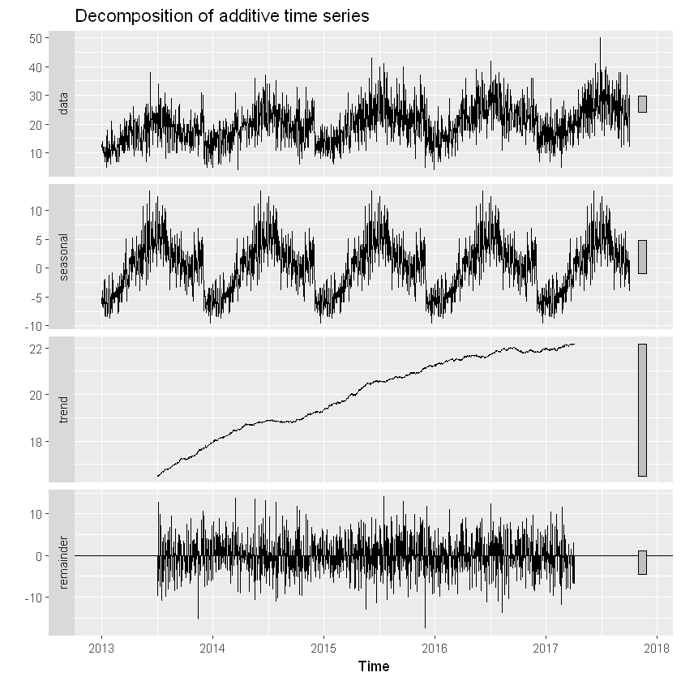

```r
train_ts_components <- decompose(sales_ts)
autoplot(train_ts_components)
```

> The plot above shows the original time series (top), the estimated seasonal component (second), the estimated trend (third) and the estimated residuals component (bottom). We can see that the trend is increasing over time and there is a similar pattern every one year. The remainder plot shows what is left over when the seasonal and trend components have been removed from the data. If we add up the last three components, we can reconstruct the original time series.

### Holt-Winters Exponential Smoothing

Holt-Winters exponential smoothing approximates the level, slope and seasonal component at the current time point. Unlike moving average, exponential smoothing technique smoothes time series using exponential window function, where the decreasing weights are assigned exponentially over time. The weight are controlled by three parameters: alpha, beta and gamma which range between 0 and 1. Value closer to 0 mean that little weight is placed on the recent observations and vice versa. This method is often used for short-term forecast of time series that can be described using an additive model. We can simply use *HoltWinters* function to apply this algorithm on our data.

```r
train_ts_HWES <- HoltWinters(sales_ts)
train_ts_HWES
```

```
Holt-Winters exponential smoothing with trend and additive seasonal component.

Call:
HoltWinters(x = sales_ts)

Smoothing parameters:
 alpha: 0.01828328
 beta : 0
 gamma: 0.467529

Coefficients:
              [,1]
a     23.753319937
b      0.006830977
s1    -1.095755526
s2     1.157699371
s3    -5.958590244
s4    -3.342435500
s5    -2.247900500
s6     0.761788930
s7     2.858266719
s8    -0.748854335
s9    -3.793019017
s10   -4.289068354
s11   -2.651359515
s12    3.120097524
s13    3.477178827
s14   -0.285191519
s15   -1.841110401
s16   -2.843174760
s17   -2.359001940
s18    2.614739609
s19   -2.501394541
s20    1.945672671
s21   -1.365326758
s22   -0.724373709
s23   -5.475492996
s24   -5.728835734
s25   -4.931942179
s26   -5.167751972
```

[output cut: 324 more lines]

```
s351   2.656204521
s352  -1.795566999
s353  -2.506553364
s354  -1.853038378
s355   2.628593617
s356   6.497805176
s357   0.290076019
s358  -3.379535443
s359  -2.879107723
s360  -0.826973492
s361   0.357787530
s362   2.149704354
s363   2.211638840
s364  -3.131153096
s365  -5.068396634
```

> The alpha, beta and gamma values showed in the output above are 0.018,0 and 0.468 respectively. Since the alpha value is extremely small, it indicates that considerable weights are placed on the less recent observations. The beta value of 0 tells us that the estimate of the slope is constant over time.

We can plot the Holt-Winters model with the forecasted values as a red line on top of the original time series.

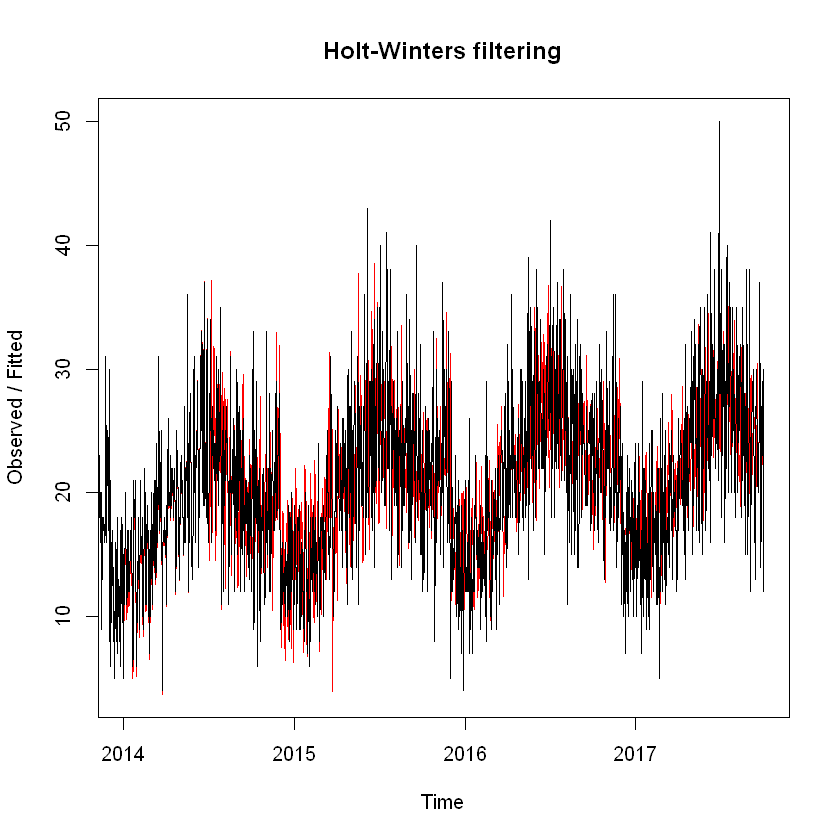

```r
plot(train_ts_HWES)
```

> From the plot we can tell that this method is fairly good in predicting the seasonal trend.

To make future prediction, we use the *forecast.HoltWinters* function from the *forecast* package.

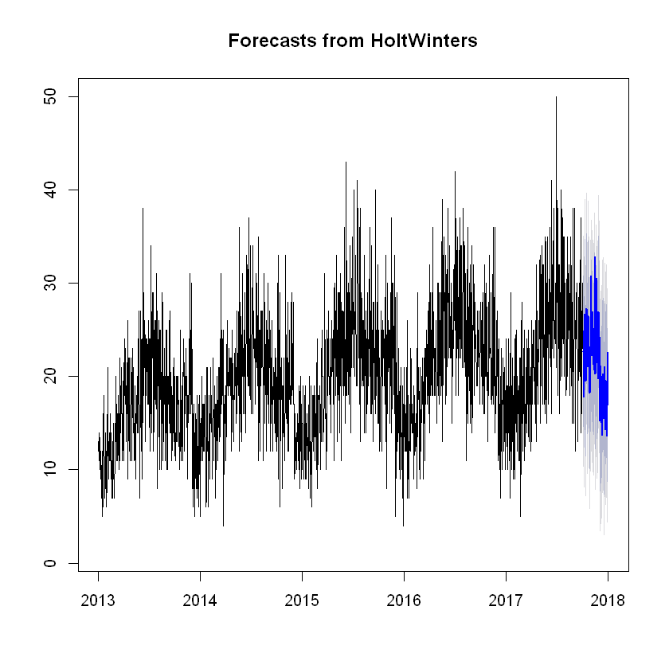

```r
# predict
train_ts_HWES_forecast <- forecast:::forecast.HoltWinters(train_ts_HWES, h=90)

# plot prediction
forecast:::plot.forecast(train_ts_HWES_forecast)
```

**Prediction Result**

For evaluation, we use *rmse* and *smape* metrics.

```r
predicted <- as.numeric(train_ts_HWES_forecast$mean)
actual <- sales_test_data
```

```r
paste('RMSE:',rmse(actual, predicted))
```

'RMSE: 5.77819430726569'

```r
paste('SMAPE:',smape(actual,predicted))
```

'SMAPE: 0.21963333149129'

The result is actually pretty good. But let's move forward to a slightly more complex model.

### ARIMA

Exponential smoothing methods are relatively simple and useful for making forecasts. However, it does not make assumptions on the correlations between the observations. Thus, to improve the predictive power of a model, accounting for correlation between data may be necessary. Autoregressive Integrated Moving Average (ARIMA) model includes trends, level shifts and seasonal pulses in the equation and it assumes correlation between successive time sequenced observations. ARIMA model describes movements in a stationary time series as a function of *AR (Autoregressive)* and *MA (Moving Average)* parameters. An AR component denoted by p parameter refers to the use of lagged values in the regression equation for the series. An MA component denoted by q paramter is the model error as a combination of previous term.

**Non-seasonal ARIMA**

Non-seasonal ARIMA is specified by three order parameters:(p,d,q). The p parameter specifies the number of lags used in the model, d refers to the order of differencing and d determines the number of terms to be included in the model. The process of fitting an ARIMA model is known as the Box-Jenkins method.

**Differencing**

As mentioned, fitting an ARIMA model requires a stationary time series. In general, a time series is stationary when its mean, variance, and autocovariance are time invariant. Theoretically, a time series with trend or seasonality is not considered stationary, as the value of the series is affected at different time point. Differencing can help to stabilize the mean of time series by reducing the level change thus eliminating the trend.

**ACF plot**

Autocorrelation plots (ACF) are useful in determining whether a series is stationary. The series is said to have trend or seasonal components when it is correlated with its lags, suggesting inconstant statistical properties over time. Let's take a quick look at the ACF plot of the sales time series.

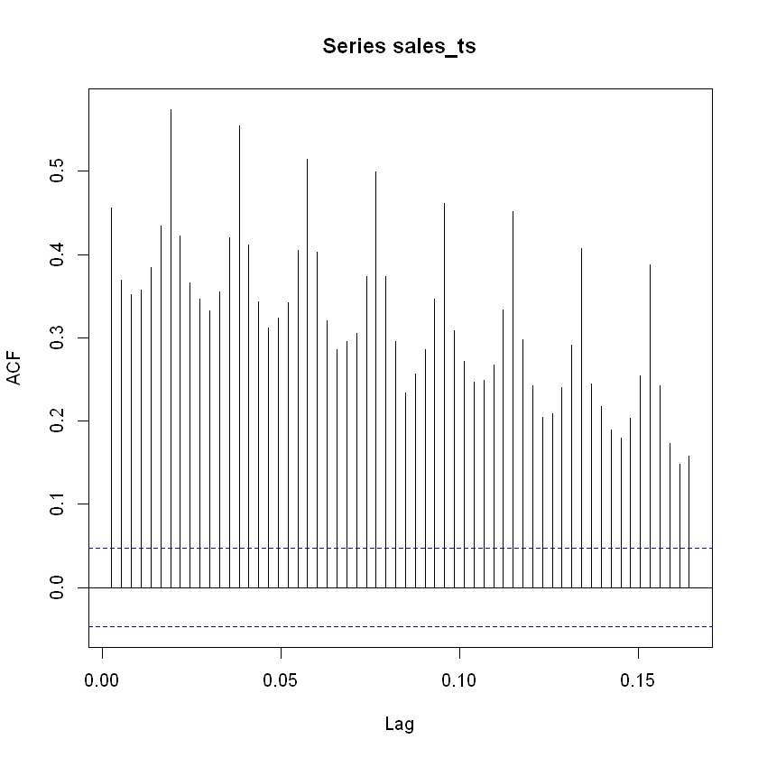

```r
acf(sales_ts,lag=60)
```

> The above ACF of the time series is decreasing slowly and the autocorrelations remain well above the significance range. This indicates that the time series is non-stationary.

We can check the differencing order using the *ndiffs* function:

```r
# check order of differencing
ndiffs(sales_ts)
```

1

It appears that we should apply a first order differencing on the data to make it stationary.

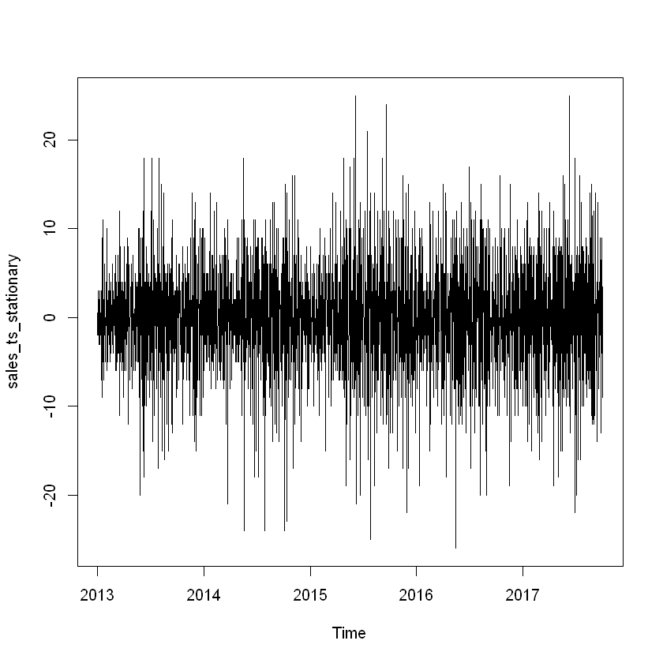

```r
# first differencing
sales_ts_stationary <- diff(sales_ts, differences = 1)
plot.ts(sales_ts_stationary)
```

Let's check the ACF of the differenced time series.

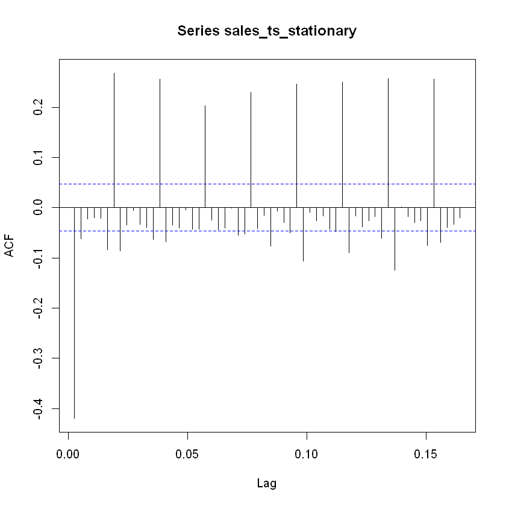

```r
acf(sales_ts_stationary,lag=60)
```

> Note that the ACF drops to zero very quickly. This is indicative of a stationary series.

**PACF plot**

Partial autocorrelation plots (PACF) display correlation between a variable and its lags that is not explained by previous lags. PACF plot is useful in determining the order of the AR model.

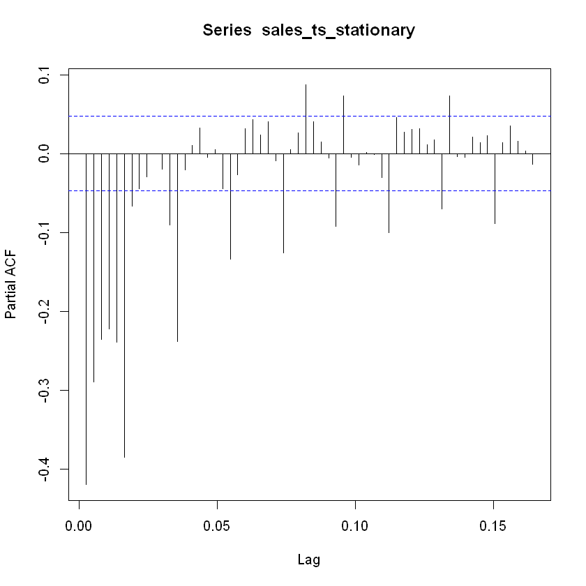

```r
pacf(sales_ts_stationary,lag=60)
```

> The partial correlogram demonstrates that the partial autocorrelations at the first few lags all exceed the significance bound and they are slowly decreasing in magnitude with increasing lag.

In the classical ARIMA, the main problem is to decide which specification to use, that is, how many order of AR and MA term to include. Since we know that the order of differencing is 1, we can use the ACF plot and PACF plot above to determine the p and q parameters. We will also be trying out different models and select the one with the lowest AIC value.

**ARIMA(0,1,1)**

The ACF plot suggest a MA(1) structure, since the autocorrelogram tails off to zero after lag 1.

```r
arima1 <- arima(sales_ts,order=c(0,1,1))
arima1
```

```
Call:
arima(x = sales_ts, order = c(0, 1, 1))

Coefficients:
          ma1
      -0.9150
s.e.   0.0082

sigma^2 estimated as 29.1:  log likelihood = -5387,  aic = 10776.01
```

**ARIMA(1,1,0)**

The PACF plot suggest an AR(1) structure, due to the significant first lag and the tapering pattern in the ACF plot.

```r
arima2 <- arima(sales_ts,order=c(1,1,0))
arima2
```

```
Call:
arima(x = sales_ts, order = c(1, 1, 0))

Coefficients:
          ar1
      -0.4202
s.e.   0.0218

sigma^2 estimated as 41.15:  log likelihood = -5686.6,  aic = 11375.21
```

**ARIMA(7,1,0)**

We can also try with a AR(7) structure since the first 7 lags are significant in PACF plot.

```r
arima3 <- arima(sales_ts,order=c(7,1,0))
arima3
```

```
Call:
arima(x = sales_ts, order = c(7, 1, 0))

Coefficients:
          ar1      ar2      ar3      ar4      ar5      ar6      ar7
      -0.8432  -0.7953  -0.7412  -0.6738  -0.5793  -0.4497  -0.0732
s.e.   0.0240   0.0295   0.0323   0.0331   0.0323   0.0295   0.0240

sigma^2 estimated as 26.77:  log likelihood = -5314.73,  aic = 10643.46
```

**ARIMA(7,1,7)**

```r
arima4 <- arima(sales_ts,order=c(7,1,7))
arima4
```

```
Call:
arima(x = sales_ts, order = c(7, 1, 7))

Coefficients:
          ar1      ar2      ar3      ar4      ar5      ar6     ar7     ma1
      -0.9789  -0.9792  -0.9793  -0.9790  -0.9793  -0.9786  0.0206  0.0903
s.e.   0.0268   0.0268   0.0268   0.0268   0.0268   0.0268  0.0267  0.0122
         ma2     ma3     ma4     ma5     ma6      ma7
      0.1030  0.0997  0.1012  0.1010  0.1005  -0.8899
s.e.  0.0113  0.0115  0.0126  0.0116  0.0115   0.0126

sigma^2 estimated as 21.68:  log likelihood = -5140.04,  aic = 10308.08
```

By far ARIMA(7,1,7) has achieved the lowest aic value which is 10308, let's further interpret the model by plotting its residuals.

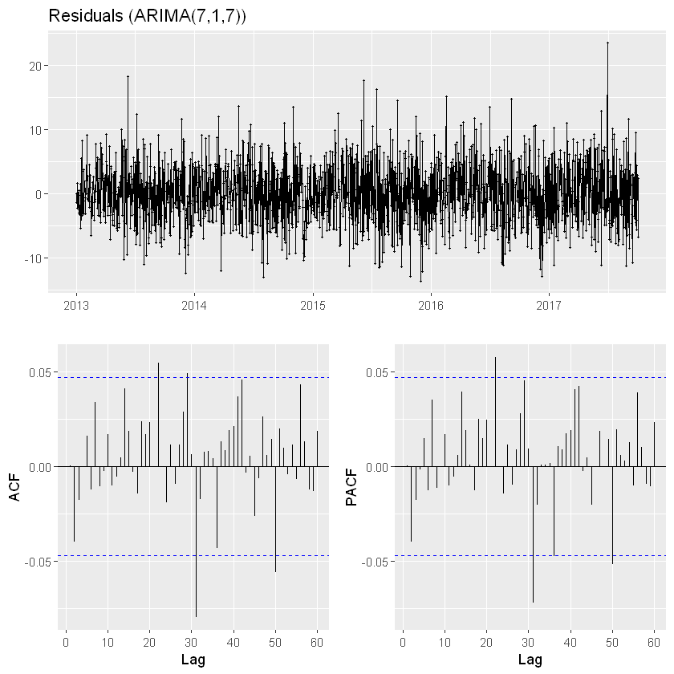

```r
ggtsdisplay(residuals(arima4),lag.max=60,main = 'Residuals (ARIMA(7,1,7))')
```

> The ACF plot shows that the autocorrelation is not particularly large, although a few significant spikes are spotted.

Let's see if our model will be better off by adding a seasonal component.

**Seasonal ARIMA**

Seasonal Autoregressive Integrated Moving Average (SARIMA) is an extension of ARIMA that supports time series with a seasonal component. Additional paramters are introduced in SARIMA where we need to specify the period of seasonality, AR/MA seasonal term and seasonal differencing degree.

Time series plot of our sales data shows that the series is strongly non-stationary and seasonal. In the ACF plot, peaks occur every 7 lags. So, we need to do a seasonal differencing on the data where period = 7. A seasonal difference is the difference between an observation and the previous observation from the same season.

[figure not shown]

```r
# seasonal differencing
sales_ts_seadiff <- diff(sales_ts, lag=7, differences=1)
plot(sales_ts_seadiff, type="l", main="Seasonally Differenced Time Series")
```

> Visual inspection of the plot indicates a stationary series.

We can confirm it by using the *ndiffs* function to check whether first differencing is required.

```r
# check order of differencing
ndiffs(sales_ts_seadiff)
```

0

There is no need for further differencing since the seasonal differenced time series is already in stationary form.

**ACF Plot for seasonal differenced series**

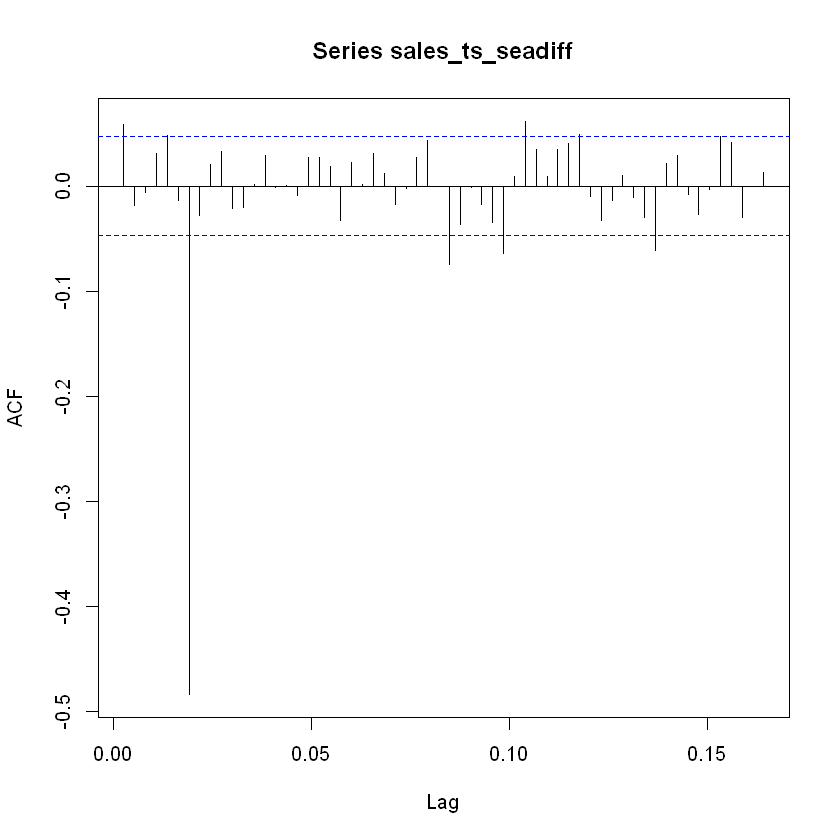

```r
acf(sales_ts_seadiff,lag=60)
```

**PACF Plot for seasonal differenced series**

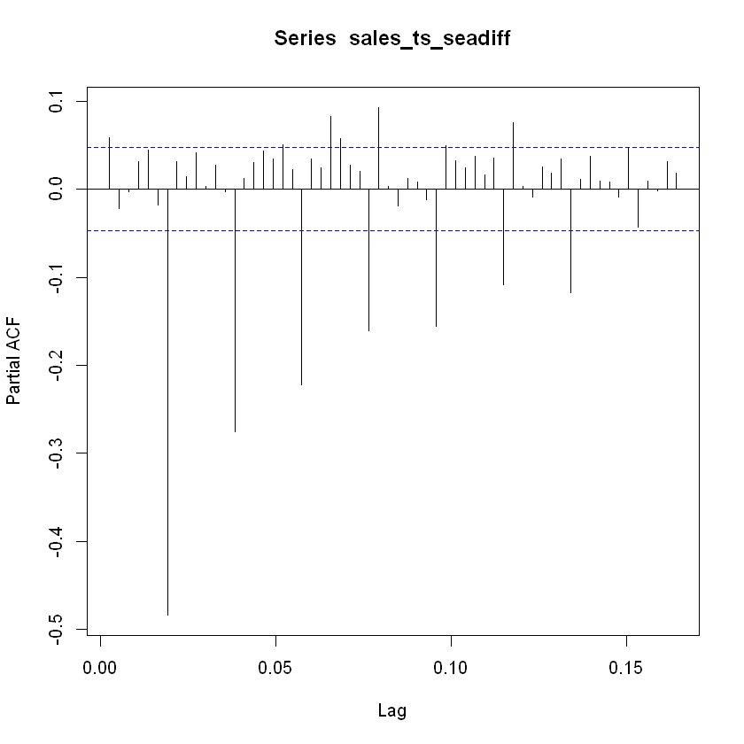

```r
pacf(sales_ts_seadiff,lag=60)
```

For SARIMA model, we will also try out different variation of the model and select the best one for final prediction.

**ARIMA(0,0,0)(1,1,0)[7]**

There is a significant spike at the first seasonal lag in the PACF.

```r
sarima1 <- arima(sales_ts, order = c(0, 0, 0), seasonal=list(order=c(1,1,0), period=7))
sarima1
```

```
Call:
arima(x = sales_ts, order = c(0, 0, 0), seasonal = list(order = c(1, 1, 0),
    period = 7))

Coefficients:
         sar1
      -0.4837
s.e.   0.0210

sigma^2 estimated as 29.74:  log likelihood = -5386.97,  aic = 10775.94
```

**ARIMA(0,0,0)(0,1,1)[7]**

There is an exponential decay in the seasonal lags in PACF and a single large significant spike found in lag 7 in ACF.

```r
sarima2 <- arima(sales_ts, order = c(0, 0, 0), seasonal=list(order=c(0,1,1), period=7))
sarima2
```

```
Call:
arima(x = sales_ts, order = c(0, 0, 0), seasonal = list(order = c(0, 1, 1),
    period = 7))

Coefficients:
         sma1
      -0.7014
s.e.   0.0166

sigma^2 estimated as 25.65:  log likelihood = -5260.66,  aic = 10523.32
```

**ARIMA(1,0,1)(0,1,1)[7]**

The significant spike at lag 1 in the ACF suggests a non-seasonal MA(1) component and the significant spike at lag 1 in the PACF suggests a non-seasonal AR(1) component.

```r
sarima3 <- arima(sales_ts, order = c(1,0,1), seasonal=list(order=c(0,1,1), period=7))
sarima3
```

```
Call:
arima(x = sales_ts, order = c(1, 0, 1), seasonal = list(order = c(0, 1, 1),
    period = 7))

Coefficients:
         ar1      ma1     sma1
      0.9943  -0.8916  -0.9910
s.e.  0.0034   0.0108   0.0069

sigma^2 estimated as 21.67:  log likelihood = -5124.88,  aic = 10255.77
```

As shown, ARIMA(1,0,1)(0,1,1)[7] achieves lowest aic score which is 10255.77.

**Residual diagnotics of ARIMA(1,0,1)(0,1,1)[7]**

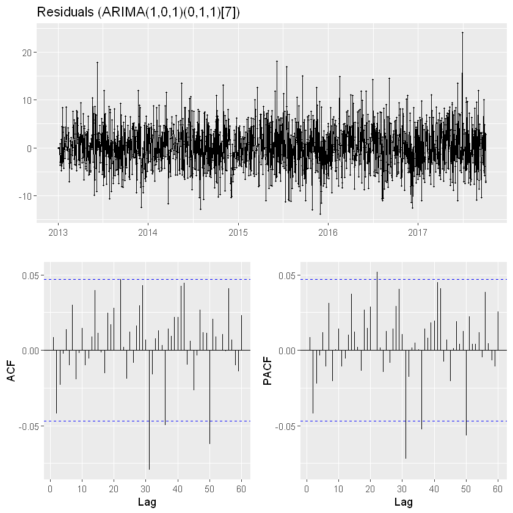

```r
ggtsdisplay(residuals(sarima3),lag.max=60,main = 'Residuals (ARIMA(1,0,1)(0,1,1)[7])')
```

> Although the residual ACF of seasonal ARIMA and non-seasonal ARIMA look similar, more lags remain in the significance bound in the ACF.

```r
# Make prediction
sarima3$x <- sales_ts
sales_ts_arima_forecast <- forecast(sarima3,h=90)
```

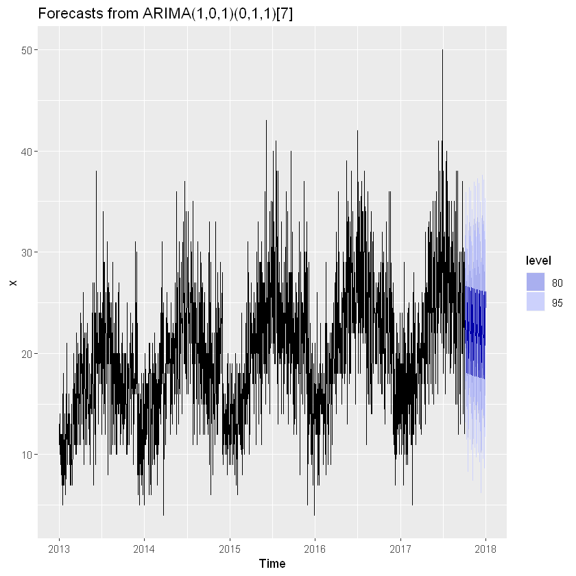

```r
# Plotting prediction
autoplot(sales_ts_arima_forecast)
```

**Predicttion result**

```r
predicted <- as.numeric(sales_ts_arima_forecast$mean)
actual <- sales_test_data
```

```r
paste('RMSE:',rmse(actual,predicted))
```

'RMSE: 5.57535299816996'

```r
paste('SMAPE:',smape(actual,predicted))
```

'SMAPE: 0.23713634647088'

### XGBoost

XGboost or eXtreme Gradient Boosting is an optimized version of distributed gradient boosting library. In boosting, trees are grown based on the information of the previously grown trees. It slowly learns from past data and tries to improve its prediction in subsequent iterations. XGboost is generally faster, more flexible and with higher predictive power as it is enabled with internal cross validation function. In addition, it is able to search for important variables in the data.

We will do a basic implementation of XGBoost here to predict future sales. First thing we'll do is to preprocess the data for the model.

```r
# Read and partition data
train_data <- read.csv('train.csv',header = TRUE)
train_data <- train_data %>% filter( store == 1 & item == 1)

partition_index <- dim(train_data)[1] - 90
xgb_train_data <- train_data[1:partition_index,]
xgb_test_data <- train_data[(partition_index+1):dim(train_data)[1],]

xgb_train_data['train_or_test'] <- 'train'
xgb_test_data['train_or_test'] <- 'test'
xgb_test_data['sales'] <- NA
data <- rbind(xgb_train_data,xgb_test_data)
```

We will create and include other variables in the data such as month, day, day mean, day median etc.

```r
data['month'] = month(train_data$date)
data['day'] = wday(train_data$date)

data <- data %>%
  group_by(year,day) %>%
  mutate(day_mean = mean(sales,na.rm = TRUE),
         day_median = median(sales,na.rm = TRUE)
  )

data <- data %>%
  group_by(month) %>%
  mutate(month_mean = mean(sales,na.rm = TRUE),
         month_median = median(sales,na.rm = TRUE)
  )
```

```r
train = subset(data, train_or_test == 'train')
test = subset(data, train_or_test == 'test')

drop.cols <- c('date','sales','train_or_test')
x_train = select(train, -one_of(drop.cols))
y_train = train$sales
```

**Training the XGBoost model**

```r
set.seed(123)

previous_na_action = options('na.action')
options(na.action='na.pass')

#Build matrix input for the model
trainMatrix = sparse.model.matrix( ~ store + item + month + day + day_mean + day_median + month_mean + month_median , data = train,
                                  contrasts.arg = c('store', 'item','month','day'),
                                  sparse = FALSE,
                                  sci = FALSE)


options(na.action = previous_na_action$na.action)

# Using linear boosting algorithm
params <- list(booster = "gbtree"
              , objective = "reg:linear"
)

trainDMatrix = xgb.DMatrix(trainMatrix, label = y_train, missing = NA)


model = xgb.train(data = trainDMatrix
                  , param = params
                  , maximize = FALSE, evaluation = 'rmse', nrounds = 50)

previous_na_action = options('na.action')
options(na.action='na.pass')

# Build matrix input for the model
testMatrix = sparse.model.matrix( ~ store + item + month + day + day_mean + day_median + month_mean + month_median, data = test,
                                  contrasts.arg = c('store', 'item','month','day'),
                                  sparse = FALSE,
                                  sci = FALSE)

options(na.action = previous_na_action$na.action)
```

**Prediction**

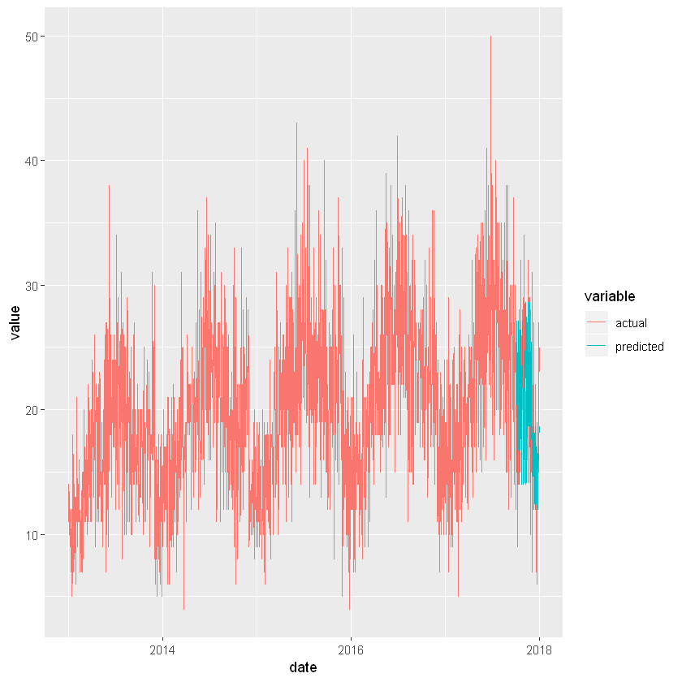

```r
# Predict values for a given day
pred <- predict(model, testMatrix)

temp <-train_data[(partition_index+1):dim(train_data)[1],]

data[is.na(data$sales),]$sales <- temp$sales
data$date <- as.Date(data$date)
pred_df <- data.frame(date = as.Date(test$date), predicted = pred)

plot_data <- merge(data, pred_df, by="date",all=TRUE)

colnames(plot_data)[colnames(plot_data) == 'sales'] <- 'actual'
plot_data <- plot_data %>% select(date, actual, predicted) %>% melt(id ="date")

ggplot(data=plot_data,
       aes(x=date, y=value, colour=variable)) +
       geom_line()
```

**Prediction Result**

```r
paste('RMSE:',rmse(temp$sales,pred))
```

'RMSE: 5.46680639908812'

```r
paste('SMAPE:',smape(temp$sales,pred))
```

'SMAPE: 0.231876011924457'

## Conclusion

In this notebook we have applied three different widely used models for our time series forecast. Based on the prediction result, Holt-Winters Exponential Smoothing has achieved the lowest SMAPE while XGBoost has achieved the lowest RMSE, although there is only little differences between the result of all three models.

While there is still room for improvement in the above application, through this project, I have learnt the following pros and cons of each method:

**Holt-Winters Exponential Smoothing**

**Pros:**

- Simple and fast, since it automatically capture the trend of time series and adjust its parameters accordingly.
- High predictive power

**Cons:**

- Only predict one time series at a time. For 10 stores and 50 items that is a total of 500 time series.

**ARIMA/SARIMA**

**Pros:**

- Robust as it includes the correlation of the observations and the previous error term for forecasting.

**Cons:**

- Only predict one time series at a time
- steep learning curve, has more parameters to specify
- must check for trend and seasonality beforehand

**XGBoost**

**Pros:**

- High predictive power
- Able to do prediction for multiple time series at a time

**Cons:**

- Slow implementation
- need to optimize many parameters and create additional features that allow it to capture trend and seasonlity